# stringr

George Zhou

*Presented 6/19/2020*

## Introduction

The library stringr created to work with/manipulate strings in R. It is a wrapper of the library *stringi*, which uses ICU C library to provide fast, easy, and correct implementation functions.

stringr is a core library in the *tidyverse* world. You just need to install tidyverse to be able to enjoy stringr!

## So what can stringr actually do?

A lot actually. Here are some examples of functions in the stringr package.

### str_count

```r
string='I love R so so much. R is the best thing since sliced bread. Would you agree with me that R is the greatest thing that has happened to you?'
pattern='R'
str_count(string,pattern)
```

```
## [1] 3
```

You are also able to use regex patterns.

```r
#How many capital words are there?
string='One fish, Two fish, Red fish, Blue fish. Black fish, Blue fish, Old fish, New fish.'
pattern='[A-Z]'
str_count(string,pattern)
```

```
## [1] 8
```

### str_replace_all

[str_replace_all](https://www.rdocumentation.org/packages/stringr/versions/1.4.0/topics/str_replace) Replaces all matched patterns within each string.

There is also a str_replace function that replaces the first matched pattern in a string.

```r
string='I am a proud Wolverine. I will forever and always be a Wolverine. Wolverines for life!'
pattern='Wolverine'
replacement='Badger'
str_replace_all(string,pattern,replacement)
```

```
## [1] "I am a proud Badger. I will forever and always be a Badger. Badgers for life!"
```

```r
#str_replace only changes the first match
str_replace(string,pattern,replacement)
```

```
## [1] "I am a proud Badger. I will forever and always be a Wolverine. Wolverines for life!"
```

```r
string1='He is pretty cool. She is pretty cool. Kanye is pretty cool.'
pattern1='[A-Z]{1}[a-z]*'
replacement1='George'
str_replace_all(string1,pattern1,replacement1)
```

```
## [1] "George is pretty cool. George is pretty cool. George is pretty cool."
```

### str_split_fixed

str_split_fixed splits a vector of strings into a matrix of substrings.

```r
string=c('Sam Sung','Joe King','Horace Cope','Chandler Eere','Walter Slide','Ray Sing','Al E. Gator')
#n is number of pieces to return
pattern=' '
str_split_fixed(string,pattern,n=2)
```

```
##      [,1]       [,2]
## [1,] "Sam"      "Sung"
## [2,] "Joe"      "King"
## [3,] "Horace"   "Cope"
## [4,] "Chandler" "Eere"
## [5,] "Walter"   "Slide"
## [6,] "Ray"      "Sing"
## [7,] "Al"       "E. Gator"
```

### str_detect and str_which, str_extract_all

str_detect and [str_which](https://www.rdocumentation.org/packages/stringr/versions/1.4.0) perform similar functions as grepl and grep respectively.

[str_extract_all](https://www.rdocumentation.org/packages/stringr/versions/0.6.2/topics/str_extract) will pull the texts that matched with the pattern.

```r
string=c('Never ever!','Gonna get some cookies!','Give it to me!','You are awesome!','Up up and away!')
pattern='^[A-Z]{1}[a-z]*'
#is there a first word that is capitalized?
str_detect(string,pattern)
```

```
## [1] TRUE TRUE TRUE TRUE TRUE
```

```r
#which strings has a capital first word?
str_which(string,pattern)
```

```
## [1] 1 2 3 4 5
```

```r
#extracts the matched word
str_extract(string,pattern)
```

```
## [1] "Never" "Gonna" "Give"  "You"   "Up"
```

## So why stringr?

stringr offers functions that may have already been covered in base R. So why use it?

### Speed

One reason to use stringr over base R is the processing speed is much faster.

In this example, we will using vector sentences, which is a vector of sentences.

```r
head(sentences)
```

```
## [1] "The birch canoe slid on the smooth planks."
## [2] "Glue the sheet to the dark blue background."
## [3] "It's easy to tell the depth of a well."
## [4] "These days a chicken leg is a rare dish."
## [5] "Rice is often served in round bowls."
## [6] "The juice of lemons makes fine punch."
```

```r
results=bench::mark(
  base=grep('The',sentences),
  stringr=str_which(sentences,'The'),iterations = 1000,time_unit = 's')
results
```

```
## # A tibble: 2 x 6
##   expression      min   median `itr/sec` mem_alloc `gc/sec`
##   <bch:expr>    <dbl>    <dbl>     <dbl> <bch:byt>    <dbl>
## 1 base       0.00416  0.00457       212.    4.02KB    0.425
## 2 stringr    0.000217 0.000242     3978.    6.88KB    0
```

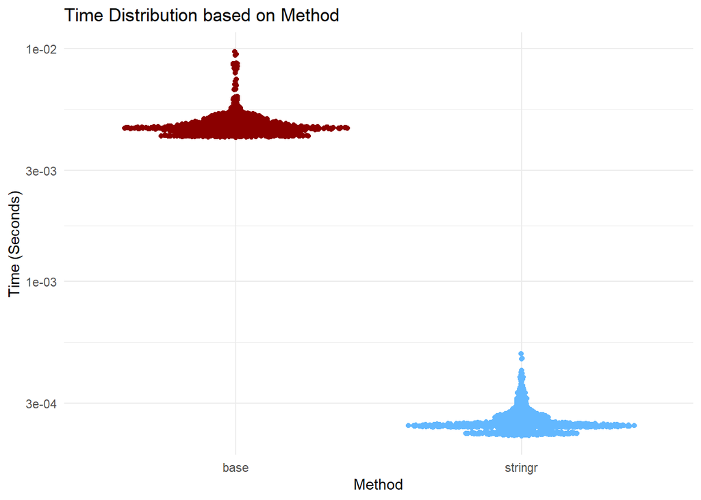

```r
dat=data.frame(Method=c(rep('base',1000),rep('stringr',1000)),Time=c(results$time[[1]],results$time[[2]]))
ggplot(dat,aes(Method,Time))+
  geom_quasirandom(aes(color=Method))+
  scale_y_log10(name='Time (Seconds)')+
  scale_color_manual(values=c('red4','steelblue1'))+
  ggtitle("Time Distribution based on Method")+
  theme_minimal()+
  theme(legend.position = 'none')
```

### Simplicity

Another reason to use stringr functions is the syntax is simpler in some cases, such as when piping.

```r
new=sentences%>%str_detect('The')
#compared to
old=sentences%>%grepl('The',.)
```

Many tasks that you would want to do in base R might need extra steps, whereas in stringr, you only need to use one function.

```r
string=c("Thank goodness it is Friday! Friday is the best day in the world! Mondays are superior!")
pattern='Friday'
string1=unlist(strsplit(string,split ="!"))
sum(grepl(pattern,string1))
```

```
## [1] 2
```

```r
#same results, less code needed
str_count(string,pattern)
```

```
## [1] 2
```

### Times where Base might be better

There are times where you may want to use base R instead. In some cases, stringr functions need helper functions to do its tasks properly. Base functions have built in arguments so there is no need for helper functions

```r
#Exact matched cases
string=c('Yay.Friday','Yay it is Friday!')
pattern='Yay.Friday'

grepl(pattern,string,fixed = T)
```

```
## [1]  TRUE FALSE
```

```r
#same results, helper function needed
str_detect(string,fixed(pattern))
```

```
## [1]  TRUE FALSE
```

## Conclusion

- stringr is a library enclosed in tidyverse built to make string manipulation easy
- Advantages in using stringr is usability, speed, and efficiency
- Disadvantages include not being versatile and need of helper functions in some cases

## Resources

- [stringr website](https://stringr.tidyverse.org/) (includes stringr cheat sheet!)
- [regex documentation](https://rstudio.com/wp-content/uploads/2016/09/RegExCheatsheet.pdf)
- [R for Data Science Strings Chapter](https://r4ds.had.co.nz/strings.html)
- [stringi Documentation](https://cran.r-project.org/web/packages/stringi/index.html)